# Estudio de la perspectiva de género en los trabajos no remunerados

- Show All Code
- Hide All Code
- View Source

Author

Marta Belenguer, Rocío Ortega, Agatha Del Olmo

Published

April 7, 2025

```r
library(ggplot2)
library(reshape2)
library(readr)
library(patchwork)
```

## 0.Introducción

El objetivo principal de esta práctica es analizar de manera crítica y detallada el impacto social y económico del tiempo que las personas asalariadas destinan a trabajos no remunerados en nuestro país. El trabajo no remunerado, generalmente asociado a las tareas domésticas y de cuidado, representa una contribución esencial, aunque invisibilizada, al bienestar social y económico. Aunque estas actividades (tareas domésticas, cuidados familiares, labores comunitarias, etc.) no reciben una compensación monetaria, su contribución al bienestar colectivo es indiscutible. A lo largo de los años, diversos estudios han resaltado la necesidad de medir y reconocer el valor real de estos trabajos, ya que comprender su magnitud no solo permitiría estimar el aporte económico oculto que generan, sino que también ofrecería pistas sobre desigualdades de género y sobre la configuración de roles familiares.

Vamos a orientar nuestra reflexión con preguntas clave como: ¿Qué impacto tendría sobre la economía estatal si estas tareas fueran remuneradas? ¿Cómo podríamos cuantificar monetariamente estas actividades? ¿Cambiaría nuestra percepción y organización del trabajo asalariado si se reconociera económicamente este trabajo? ¿Cómo afectaría esto a los roles familiares tradicionales y cómo modificaría las desigualdades por razón de género existentes? Aunque no vamos a proporcionar respuestas definitivas a estas preguntas, sí las vamos a utilizar para dirigir adecuadamente nuestra investigación, que se ubica en el ámbito del muestreo estadístico. Específicamente, nuestra contribución se centrará en diseñar una muestra representativa que permita obtener información relevante sobre estos aspectos, prestando especial atención al sesgo de género que habitualmente acompaña a los trabajos no remunerados.

Como esta práctica forma parte de la asignatura de muestreo, nos vamos a centrar sobre todo en cómo diseñar la muestra. De manera tradicional, una muestra representativa se define como aquella que reproduce las características de la población de interés (en este caso, la población asalariada que realiza o podría realizar tareas no remuneradas) de forma proporcional o ajustada a ciertos criterios estadísticos. Sin embargo, la indicación de la agente de igualdad introduce la necesidad de contemplar el sesgo derivado de la variable “género”, ya que históricamente la distribución de tareas de cuidados y del hogar suele recaer de forma desigual en mujeres y hombres. Así, un grupo será verdaderamente representativo si se corrige o, al menos, se visibiliza este sesgo de género, de tal manera que los hallazgos reflejen fielmente la realidad de ambas poblaciones (hombres y mujeres) y permitan extraer conclusiones con validez estadística y social.

Numerosos informes y estadísticas, incluido el propio Instituto Nacional de Estadística (INE), muestran que las mujeres invierten un mayor número de horas diarias en trabajos no remunerados. Si se seleccionara una muestra proporcional únicamente a la distribución global de asalariados, podría ocurrir que la perspectiva femenina quedara insuficientemente representada en el análisis de las horas de trabajo no remunerado. Este subregistro dificultaría la identificación de las diferencias reales y, por tanto, la formulación de conclusiones adecuadas. En consecuencia, la práctica propone equilibrar o ajustar la proporción de hombres y mujeres en la muestra para garantizar que su experiencia en trabajos no remunerados se contemple adecuadamente. Este ajuste permite corregir o al menos disminuir el sesgo y posibilita un análisis más completo de la variable principal: el tiempo invertido en actividades no remuneradas.

Para llevar a cabo esta tarea, vamos a obtener datos oficiales del Instituto Nacional de Estadística (INE), analizando específicamente las horas dedicadas diariamente a actividades no remuneradas, segregando por género y seleccionando las actividades más pertinentes a nuestro estudio. Posteriormente, vamos a analizar estos datos identificando patrones significativos, tanto verticalmente (diferencias entre columnas) como horizontalmente (variaciones observadas en las filas). Con esta base, podremos plantear un modelo de muestreo apropiado que se ajuste a la intención investigadora y permita examinar adecuadamente el sesgo de género.

Finalmente, vamos a reflexionar sobre la calidad de los datos obtenidos, evaluando posibles mejoras en los procedimientos de recogida de información. Esta reflexión incluirá identificar variables adicionales que podrían proporcionar una comprensión más profunda y matizada del fenómeno estudiado, especialmente respecto al tiempo real dedicado por personas que declaran altos niveles de dedicación a tareas de cuidado y domésticas.

## 1.Obtención de los datos

El propósito de este primer paso es obtener los datos oficiales del INE que nos permitan conocer el porcentaje de personas asalariadas que dedican tiempo a trabajos no remunerados, desglosado por:

- Sexo: Hombres y Mujeres.
- Actividad específica.
- Horas al día dedicadas a estas actividades.

Este paso es fundamental porque, a partir de estos datos, podremos luego hacer el análisis del sesgo de género para construir una muestra representativa que corrija estas desigualdades.

Escogemos la siguiente combinación de los datos:

- Sexo: Seleccionamos hombres y mujeres por separado, ya que la práctica indica crear dos tablas diferenciadas. Esta decisión responde al propósito central de identificar diferencias y sesgos relacionados con el género, permitiendo así análisis comparativos más precisos y la posterior construcción de una muestra representativa ajustada.

Seleccionamos exclusivamente las siguientes tres actividades:

- Cuidado y educación de sus hijos o nietos
- Cocinar y realizar las tareas domésticas
- Cuidado de familiares ancianos o con alguna discapacidad

La selección responde directamente al enfoque de la sesión con la agente de igualdad, que puso especial énfasis en la carga que representan las tareas relacionadas con el cuidado del hogar y de las personas dependientes. Además, estas actividades son especialmente relevantes para nuestras preguntas iniciales sobre el impacto económico de estos trabajos no remunerados, la configuración de los roles familiares tradicionales y las desigualdades de género que se generan o perpetúan a partir de estas cargas.

Así, nos vamos a centrar en las tareas que históricamente y socialmente recaen más sobre las mujeres y que reflejan mejor la problemática que queremos analizar.

Respecto a la variable ‘horas al día’, seleccionamos todas las opciones disponibles excepto ‘Menos de 1 hora’ y ‘NS’ (No Sabe). Por lo tanto, las opciones seleccionadas son las siguientes:

- 1 hora
- 2 horas
- 3 horas
- 4 horas
- 5 o más horas

Excluimos ‘Menos de 1 hora’ porque, aunque estas personas también contribuyen, el objetivo es centrarnos en aquellas personas cuya dedicación diaria tiene un peso más significativo en términos de carga de trabajo y tiempo invertido. Queremos identificar mejor los impactos relevantes en la economía y en la vida personal y profesional de las personas asalariadas, y los datos de dedicaciones marginales (menos de una hora) pueden diluir los patrones más importantes.

Además, excluimos ‘NS’ (No sabe) para garantizar que los datos que utilicemos sean fiables y provengan de personas que pueden estimar con claridad el tiempo que dedican a estas tareas.

De este modo, focalizamos el análisis en personas asalariadas que declaran dedicar entre 1 hora y más de 5 horas diarias, lo cual nos proporcionará una visión mucho más clara de los perfiles con mayores cargas de trabajo no remunerado.

Una vez configuradas todas las selecciones, descargamos los resultados de cada combinación de variables.

```r
## Generamos una tabla para hombres:

datos_hombres <- read.csv(
  file = "datos_hombres.csv",
  sep = ";",
  fileEncoding = "Latin1",
  stringsAsFactors = FALSE
)

## Generamos una tabla para mujeres:

datos_mujeres <- read.csv(
  file = "datos_mujeres.csv",
  sep = ";",
  fileEncoding = "Latin1",
  stringsAsFactors = FALSE
)
```

## 2.Análisis de los datos

**Note**

¿Cuál puede ser la variable de estudio? ¿En qué unidades se expresará? ¿Qué datos de las tablas respaldan la información de la sesión con las agentes de igualdad?

La variable principal que vamos a estudiar es:

- Horas diarias dedicadas a trabajos no remunerados, diferenciadas por sexo y por actividad específica.

Unidad de medida:

- Porcentaje de personas asalariadas que dedican ese número de horas al día a la actividad seleccionada.

Esta variable es fundamental porque nos permite medir no solo la participación en las tareas no remuneradas, sino también la intensidad de la dedicación, que es clave para comprender las desigualdades de género en la distribución de estas cargas de trabajo.

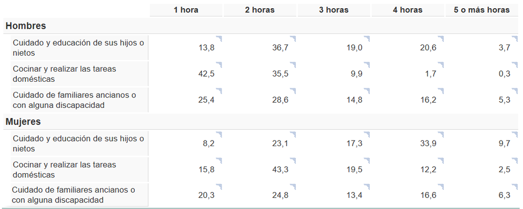

Durante la charla, la agente de igualdad destacó que las mujeres asumen, en general, una mayor carga de trabajo no remunerado, especialmente en las tareas del cuidado familiar y doméstico. Los datos que hemos obtenido respaldan esta afirmación de forma clara.

Por ejemplo, en la actividad de cuidado y educación de hijos o nietos, el porcentaje de mujeres que dedican 4 horas al día asciende al 33,9%, mientras que en los hombres se queda en un 20,6%. Además, en la misma actividad, un 9,7% de las mujeres declara dedicar 5 o más horas diarias, frente al 3,7% registrado en los hombres. En cuanto a las tareas de cocinar y realizar trabajos domésticos, los hombres que dedican 5 o más horas representan únicamente un 0,3%, mientras que, aunque no es la franja mayoritaria en las mujeres, alcanza un 2,5%.

Estos datos confirman de manera empírica que las mujeres dedican más tiempo diario a las actividades de cuidado que los hombres, especialmente en las franjas de mayor carga horaria, reflejando así una división desigual del trabajo no remunerado.

### 2.1.Análisis vertical

Este análisis implica observar la distribución de porcentajes para una misma categoría de horas diarias entre las diferentes actividades, comparando hombres y mujeres:

- Para las mujeres:
  - Observamos que en actividades de ‘Cocinar y realizar las tareas domésticas’, una proporción considerable (43,3%) dedica 2 horas diarias, siendo significativamente más alto que en las otras actividades.
  - En cuanto al ‘Cuidado y educación de hijos o nietos’, destaca el elevado porcentaje (33,9%) que dedica 4 horas diarias.
  - Para el ‘Cuidado de familiares ancianos o con alguna discapacidad’, predominan porcentajes elevados en 1 y 2 horas diarias (20,3% y 24,8%).
- Para los hombres:
  - En actividades de ‘Cocinar y realizar las tareas domésticas’, el porcentaje más alto (42,5%) se concentra en 1 hora diaria.
  - En la actividad de ‘Cuidado y educación de hijos o nietos’, se observa que la mayoría dedica 2 horas (36,7%), siendo menos frecuente un mayor tiempo.
  - Respecto al ‘Cuidado de familiares ancianos o con discapacidad’, predomina nuevamente el intervalo de 2 horas (28,6%), similar al cuidado infantil.

La interpretación vertical refleja que las mujeres tienden a dedicar más tiempo diario que los hombres, especialmente en actividades de cuidado infantil y tareas domésticas, coincidiendo claramente con las desigualdades mencionadas por la agente de igualdad.

**Mostrar código**

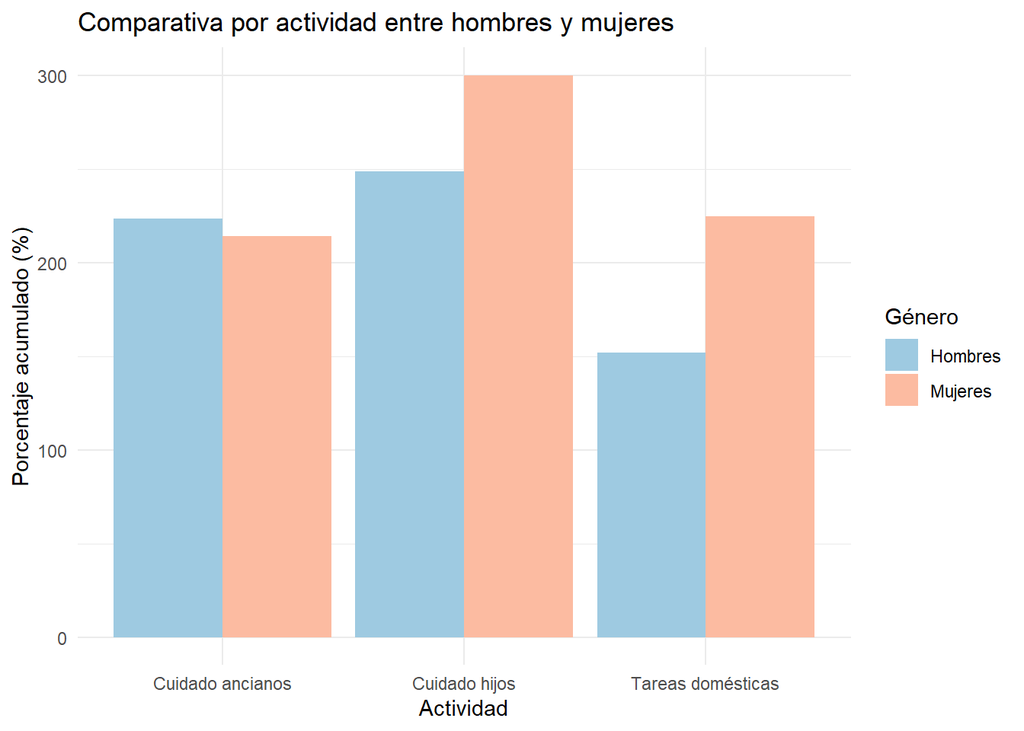

```r
actividades <- c("Cuidado hijos", "Tareas domésticas", "Cuidado ancianos")

hombres_actividades <- c(
  13.8 + 36.7*2 + 19.0*3 + 20.6*4 + 3.7*6,  ## Cuidado hijos
  42.5 + 35.5*2 + 9.9*3 + 1.7*4 + 0.3*6,   ## Tareas domésticas
  25.4 + 28.6*2 + 14.8*3 + 16.2*4 + 5.3*6  ## Cuidado ancianos
)

mujeres_actividades <- c(
  8.2 + 23.1*2 + 17.3*3 + 33.9*4 + 9.7*6,  ## Cuidado hijos
  15.8 + 43.3*2 + 19.5*3 + 12.2*4 + 2.5*6, ## Tareas domésticas
  20.3 + 24.8*2 + 13.4*3 + 16.6*4 + 6.3*6  ## Cuidado ancianos
)


df_actividades <- data.frame(
  Actividad = actividades,
  Hombres = hombres_actividades,
  Mujeres = mujeres_actividades
)


df_actividades_melt <- melt(df_actividades, id.vars = "Actividad")

ggplot(df_actividades_melt, aes(x = Actividad, y = value, fill = variable)) +
  geom_bar(stat = "identity", position = "dodge") +
  labs(title = "Comparativa por actividad entre hombres y mujeres",
       y = "Porcentaje acumulado (%)",
       x = "Actividad",
       fill = "Género") +
    scale_fill_manual(values = c("Hombres" = "#9ecae1", "Mujeres" = "#fcbba1")) +
  theme_minimal()
```

### 2.2.Análisis horizontal

Este análisis implica observar cómo varía la dedicación (en horas diarias) dentro de cada actividad específica según género:

La interpretación horizontal refuerza las desigualdades: las mujeres tienen una distribución más equilibrada pero orientada hacia períodos más largos, especialmente en actividades de crianza y domésticas, mientras que los hombres generalmente dedican menos tiempo.

**Mostrar código**

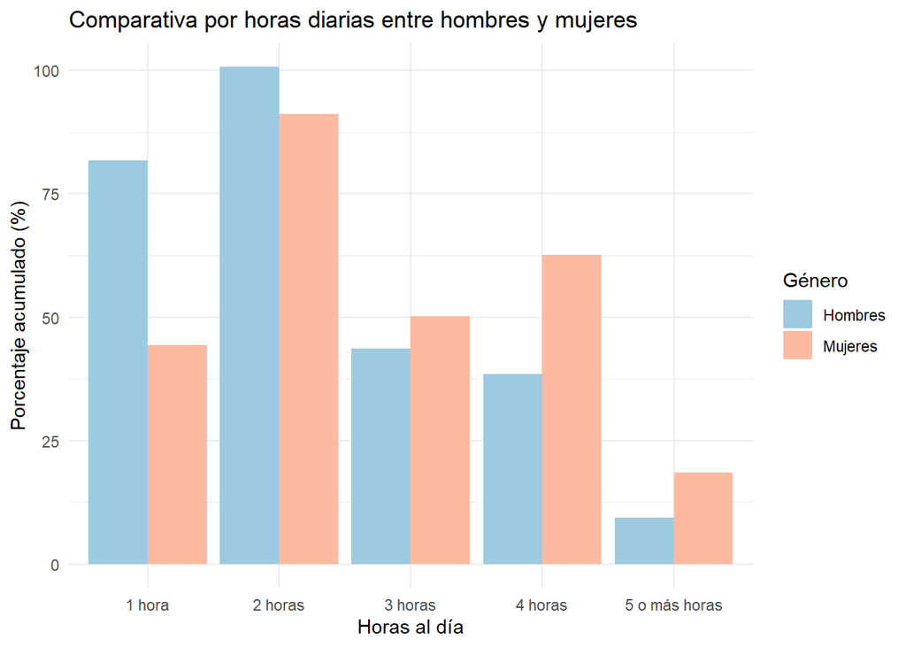

```r
horas <- c("1 hora", "2 horas", "3 horas", "4 horas", "5 o más horas")

hombres_horas <- c(
  13.8 + 42.5 + 25.4,
  36.7 + 35.5 + 28.6,
  19.0 + 9.9 + 14.8,
  20.6 + 1.7 + 16.2,
  3.7 + 0.3 + 5.3
)

mujeres_horas <- c(
  8.2 + 15.8 + 20.3,
  23.1 + 43.3 + 24.8,
  17.3 + 19.5 + 13.4,
  33.9 + 12.2 + 16.6,
  9.7 + 2.5 + 6.3
)

df_horas <- data.frame(
  Horas = factor(horas, levels = horas),
  Hombres = hombres_horas,
  Mujeres = mujeres_horas
)

df_horas_melt <- melt(df_horas, id.vars = "Horas")

ggplot(df_horas_melt, aes(x = Horas, y = value, fill = variable)) +
  geom_bar(stat = "identity", position = "dodge") +
  labs(title = "Comparativa por horas diarias entre hombres y mujeres",
       y = "Porcentaje acumulado (%)",
       x = "Horas al día",
       fill = "Género") +
  scale_fill_manual(values = c("Hombres" = "#9ecae1", "Mujeres" = "#fcbba1")) +  # puedes cambiar los colores
  theme_minimal()
```

Estos análisis verticales y horizontales apoyan firmemente la existencia de un sesgo por razón de género en el tiempo dedicado a trabajos no remunerados. Las mujeres dedican más tiempo a estas actividades en comparación con los hombres, especialmente cuando se analizan intervalos horarios más amplios.

**Mostrar código**

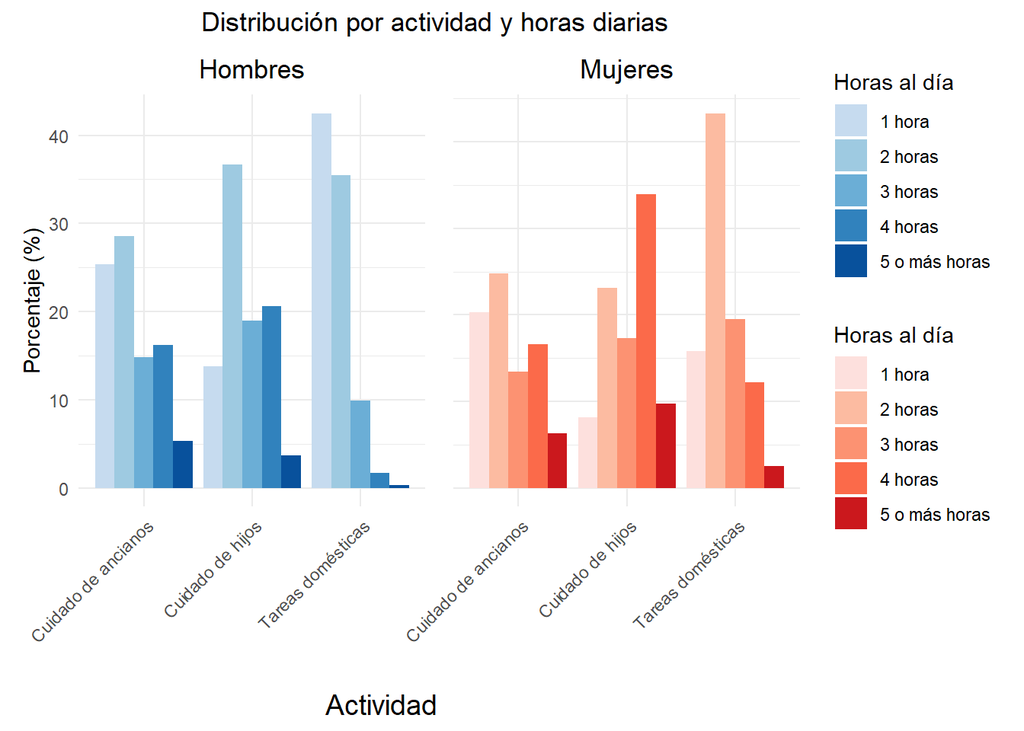

```r
df_hombres <- data.frame(
  Actividad = rep(c("Cuidado de hijos", "Tareas domésticas", "Cuidado de ancianos"), each = 5),
  Horas = rep(c("1 hora", "2 horas", "3 horas", "4 horas", "5 o más horas"), times = 3),
  Porcentaje = c(
    # Cuidado de hijos
    13.8, 36.7, 19.0, 20.6, 3.7,
    # Tareas domésticas
    42.5, 35.5, 9.9, 1.7, 0.3,
    # Cuidado de ancianos
    25.4, 28.6, 14.8, 16.2, 5.3
  )
)

df_hombres$Horas <- factor(df_hombres$Horas, levels = c("1 hora", "2 horas", "3 horas", "4 horas", "5 o más horas"))

g1<-ggplot(df_hombres, aes(x = Actividad, y = Porcentaje, fill = Horas)) +
  geom_bar(stat = "identity", position = "dodge") +
  labs(title = "Hombres",
       x = "",
       y = "Porcentaje (%)",
       fill = "Horas al día") +
  theme_minimal() +
theme(
    axis.text.x = element_text(angle = 45, hjust = 1),
    plot.title = element_text(hjust = 0.5)  # Centra el título
  ) +  scale_fill_manual(values = c(
    "1 hora" = "#c6dbef",        # Azul muy claro
    "2 horas" = "#9ecae1",       # Azul claro
    "3 horas" = "#6baed6",       # Azul medio
    "4 horas" = "#3182bd",       # Azul fuerte
    "5 o más horas" = "#08519c"  # Azul oscuro (casi morado)
  ))

df_mujeres <- data.frame(
  Actividad = rep(c("Cuidado de hijos", "Tareas domésticas", "Cuidado de ancianos"), each = 5),
  Horas = rep(c("1 hora", "2 horas", "3 horas", "4 horas", "5 o más horas"), times = 3),
  Porcentaje = c(
    # Cuidado de hijos
    8.2, 23.1, 17.3, 33.9, 9.7,
    # Tareas domésticas
    15.8, 43.3, 19.5, 12.2, 2.5,
    # Cuidado de ancianos
    20.3, 24.8, 13.4, 16.6, 6.3
  )
)

df_mujeres$Horas <- factor(df_mujeres$Horas, levels = c("1 hora", "2 horas", "3 horas", "4 horas", "5 o más horas"))

g2<- ggplot(df_mujeres, aes(x = Actividad, y = Porcentaje, fill = Horas)) +
  geom_bar(stat = "identity", position = "dodge") +
  labs(title = "Mujeres",
       x = "",
       y = "Porcentaje (%)",
       fill = "Horas al día") +
  theme_minimal() +
   theme(
    axis.text.x = element_text(angle = 45, hjust = 1),
    plot.title = element_text(hjust = 0.5)  # Centra el título
  ) +
  scale_fill_manual(values = c(
    "1 hora" = "#fde0dd",        # Rosa muy claro
    "2 horas" = "#fcbba1",       # Rosa suave
    "3 horas" = "#fc9272",       # Rojo coral claro
    "4 horas" = "#fb6a4a",       # Rojo medio
    "5 o más horas" = "#cb181d"  # Rojo intenso
  ))

g1 +
  g2 +
    theme(axis.title.y = element_blank(),
          axis.text.y = element_blank(),
          axis.ticks.y = element_blank()) +
  plot_layout(guides = "collect") +
  plot_annotation(
    title = "Distribución por actividad y horas diarias",
    caption = "Actividad",
    theme = theme(
      plot.title = element_text(hjust = 0.35),
      plot.caption = element_text(size = 14, hjust = 0.35)
    )
  )
```

## 3.Elección de la muestra

**Note**

¿Cuál se ajusta mejor a la intención de la encuesta? ¿Cuál es la variable que nos permitirá estudiar el sesgo de género en este contexto? ¿Cómo haríais la distribución por género?

Hemos elegido el muestreo estratificado como el modelo más adecuado. Este método es idóneo porque nuestro objetivo principal es corregir un sesgo conocido, específicamente el sesgo de género en el tiempo dedicado a trabajos no remunerados. El muestreo estratificado nos permitirá dividir claramente la población en estratos por género, garantizando una representación adecuada y proporcional de ambos grupos para mejorar la precisión y la fiabilidad de las conclusiones obtenidas.

La variable clave para analizar el sesgo de género en este contexto es el tiempo (ponderado por horas) que dedican las personas asalariadas a actividades de trabajo no remunerado. La diferencia en las horas ponderadas entre hombres y mujeres será fundamental para entender la magnitud del sesgo existente.

La distribución por género en nuestra muestra debería reflejar proporcionalmente la suma ponderada del tiempo dedicado a actividades no remuneradas por hombres y mujeres.

- Calculamos la proporción de cada grupo respecto al total del tiempo ponderado.
- Utilizaremos estas proporciones para decidir cuántos individuos de cada género seleccionar en la muestra, garantizando así que los resultados sean representativos y que el sesgo de género quede debidamente corregido.

```r
datos_hombres$Total <- as.numeric(gsub(",", ".", datos_hombres$Total))
datos_mujeres$Total <- as.numeric(gsub(",", ".", datos_mujeres$Total))
```

A continuación, asignamos valores numéricos específicos a cada intervalo categórico de dedicación horaria. Esto permite convertir los intervalos de tiempo en valores cuantitativos manejables, lo que facilita la comparación directa entre diferentes grupos y actividades.

```r
valores_horas <- c("Menos de 1 hora" = 0.5,
                   "1 hora" = 1,
                   "2 horas" = 2,
                   "3 horas" = 3,
                   "4 horas" = 4,
                   "5 o más horas" = 6)
```

Seguidamente, agregamos una columna nueva con estos valores numéricos ponderados a los conjuntos de datos tanto de hombres como de mujeres. Esto permite evaluar con mayor exactitud la dedicación real de tiempo en términos numéricos.

```r
datos_hombres$Horas_numericas <- valores_horas[datos_hombres$Horas.al.día]
datos_mujeres$Horas_numericas <- valores_horas[datos_mujeres$Horas.al.día]
```

Procedemos entonces a calcular la suma ponderada de horas dedicadas por cada categoría para hombres y mujeres. Este método aporta una medida agregada clara que refleja la intensidad del tiempo dedicado por cada grupo a las distintas actividades no remuneradas.

```r
hombres_ponderado <- aggregate(Horas_numericas * Total ~ Horas.al.día, data = datos_hombres, sum)
mujeres_ponderado <- aggregate(Horas_numericas * Total ~ Horas.al.día, data = datos_mujeres, sum)
```

Luego renombramos las columnas para aportar claridad al análisis, indicando específicamente los grupos analizados (Hombres y Mujeres) y finalmente, ordenamos los resultados según las categorías horarias y construimos un dataframe final que facilita la comparación directa entre la dedicación ponderada por género.

```r
colnames(hombres_ponderado)[2] <- "Hombres"
colnames(mujeres_ponderado)[2] <- "Mujeres"


hombres_ponderado <- hombres_ponderado[order(hombres_ponderado$Horas.al.día), ]
mujeres_ponderado <- mujeres_ponderado[order(mujeres_ponderado$Horas.al.día), ]


resumen_final <- data.frame(
  Horas.al.día = hombres_ponderado$Horas.al.día,
  Hombres = hombres_ponderado$Hombres,
  Mujeres = mujeres_ponderado$Mujeres
)

print(resumen_final)
```

```
     Horas.al.día Hombres Mujeres
1          1 hora  157.80  159.70
2         2 horas  425.20  264.20
3         3 horas  231.30  299.70
4         4 horas  229.60  347.60
5   5 o más horas  183.00  301.80
6 Menos de 1 hora   20.35   16.95
```

Este resumen nos muestra claramente que las mujeres superan a los hombres en las franjas de mayor dedicación horaria, especialmente a partir de las 4 horas diarias.

Estos cálculos facilitan la comprensión de la magnitud del tiempo invertido en tareas no remuneradas y ayudan a decidir la asignación muestral. Conociendo en qué franja horaria se concentra la mayor proporción de cada género, resulta más fácil planificar cuántos individuos deben seleccionarse en cada tramo para no subestimar el trabajo no remunerado. En consecuencia, el diseño se basaría en estratos según el género y en pesos que consideren la distribución horaria. Este enfoque posibilita una corrección efectiva del sesgo de género, al permitir una representación suficiente de las mujeres en los tramos de mayor dedicación. De este modo, se obtendrá una muestra realmente representativa en términos de carga de trabajo no remunerado, adaptada a los objetivos de la práctica.

```r
## Suma total de hombres:
suma_tot_hombres <- 81.7 + 201.6 + 131.1 + 154.0 + 55.8

## Suma total de mujeres:
suma_tot_mujeres <- 44.3 + 182.4 + 150.6 + 250.8 + 111.0

## Suma total general:
suma_tot_general <- suma_tot_hombres + suma_tot_mujeres

## Proporción de hombres:
suma_tot_hombres/suma_tot_general*100
```

```
[1] 45.78596
```

```r
## 45.8%

## Proporción de mujeres:
suma_tot_mujeres/suma_tot_general*100
```

```
[1] 54.21404
```

```r
## 54.2%
```

```r
# Cálculos para franjas altas

## Suma hombres (4 h + 5+ h):
suma_hombres <- 154.0 + 55.8

## Suma mujeres (4 h + 5+ h):
suma_mujeres <- 250.8 + 111.0

## Suma total (altas cargas):
suma_general <- suma_hombres + suma_mujeres

## Proporción de hombres en altas cargas::
suma_hombres/suma_general*100
```

```
[1] 36.70399
```

```r
## 36.7%

## Proporción de mujeres en altas cargas::
suma_mujeres/suma_general*100
```

```
[1] 63.29601
```

```r
## 63.3%
```

Tras estos cálculos, valoramos la necesidad de proponer un modelo de muestreo que refleje fielmente la distribución real de la población o que, al menos, permita corregir el sesgo de género detectado.

El enfoque más adecuado es el muestreo estratificado, dado que garantiza una representación equilibrada de los distintos subgrupos y se ajusta bien a la intención de la encuesta.

Vemos que, si consideramos toda la muestra, la proporción es aproximadamente equilibrada, pero ya existe una ligera sobrerrepresentación de las mujeres (54.2%). Sin embargo, en las franjas de mayor carga de trabajo no remunerado, la diferencia se amplifica notablemente: las mujeres representan el 63.3% frente al 36.7% de los hombres. Esto confirma que las mujeres no solo participan más en los trabajos no remunerados, sino que también asumen mayor carga horaria, reforzando la necesidad de corregir este desequilibrio en la muestra que vayamos a seleccionar.

Con los cálculos realizados observamos claramente cómo la proporción de mujeres aumenta considerablemente en los intervalos de tiempo más largos (4 horas o más). Esto refuerza la necesidad de aplicar un muestreo estratificado para reducir el sesgo de género.

Para seleccionar la muestra y reducir este sesgo, debemos utilizar estas proporciones calculadas. En términos prácticos, si decidimos seleccionar una muestra, deberíamos elegir aproximadamente un 54.2% de mujeres y un 45.8% de hombres si consideramos globalmente todas las categorías. Sin embargo, si deseamos investigar específicamente intervalos más largos de dedicación (4 horas o más), sería necesario aumentar proporcionalmente la representación de mujeres en la muestra, asegurando así resultados más ajustados a la realidad observada y reduciendo efectivamente el sesgo detectado.

## 4.Propuestas de mejora en la recogida de los datos

**Note**

¿Podría incorporarse alguna otra variable relevante?

En el análisis previo, obtuvimos unos resultados que, en un primer momento, nos sorprendieron. Al observar el total de horas dedicadas, las proporciones dentro de la muestra parecían bastante equilibradas. No obstante, al desagregar los datos por género y centrarnos en las personas que dedican una mayor cantidad de tiempo a las tareas no remuneradas, comenzaron a evidenciarse diferencias significativas.

Tal como señaló Dolores, la experta invitada a la sesión del pasado miércoles, es fundamental profundizar en las causas de este tipo de desigualdades. En este caso, solo podemos proponer algunas hipótesis fundamentadas en supuestos razonables. Una de las explicaciones posibles es la persistencia de roles de género tradicionales que aún hoy influyen en la distribución del tiempo dentro de los hogares. También podría deberse a una organización desigual de las responsabilidades domésticas en el entorno familiar o de pareja. Asimismo, no se puede descartar el peso de la presión social —a menudo autoimpuesta— que lleva a muchas mujeres a asumir una actitud de autoexigencia y perfeccionismo, bajo la idea de que “si no lo hago yo, no estará bien hecho”.

Para poder formular conclusiones más sólidas y menos especulativas, sería muy útil contar con un mayor número de variables en el estudio. Por ejemplo, incluir el estado civil de las personas participantes permitiría observar si existen diferencias significativas entre personas solteras, casadas o divorciadas. Otra variable relevante podría ser la convivencia con otras personas que también realicen tareas no remuneradas, ya que esto podría afectar la distribución del tiempo.

Del mismo modo, sería relevante incluir una variable que recoja el número total de personas a cargo de cada individuo —ya sean menores de edad o personas mayores—, con el objetivo de reflejar con mayor precisión las cargas de cuidado que asume cada persona. También sería pertinente incorporar una variable que indique el tipo de jornada laboral —ya sea parcial, completa, flexible o en modalidad de teletrabajo—, ya que esto aportaría información clave para interpretar cómo se organiza el tiempo y qué factores podrían estar condicionando la dedicación a las tareas no remuneradas.

Asimismo, contar con variables como la edad o el nivel económico podría enriquecer aún más el análisis: la edad permitiría identificar qué franjas de edad concentran a las personas que dedican más horas, facilitando la formulación de hipótesis más específicas; y el nivel económico podría revelar si existe una menor dedicación a este tipo de tareas entre quienes disponen de recursos para delegarlas en personas contratadas.

Incorporar estas variables nos permitiría realizar un análisis más profundo y fundamentado en datos, lo que contribuiría a obtener conclusiones más precisas, alejadas de la mera especulación.